# Лабораторная работа 6

Мезенцева Алена

18 декабря 2016 г

## Исходные данные

Базы данных The World Wealth and Income Database.

# Задание 1

1. Прочитайте файл в переменную. На основе полученных данных создайте новую переменную в которой будут следующие колонки (наблюдения): ‘Year’, ‘P99’, ‘P99.5’ и ‘P99.9’; это уровни дохода ,которые входят в 99-й, 99.5-й и 99.9 персентиль дохода. Чему равнялся P99 в 1972? P99.5 в 1942? P99.9 в 1922? Требуется найти эти значения с помощью кода, а не с помощью глаз (для удобства разумно будет переименовать колонки в данных).

```r
data.origin <- read.csv("https://raw.githubusercontent.com/SergeyMirvoda/da2016/master/lab6/wtid-report.csv")
data <- data.frame(Year=data.origin$Year, P99=data.origin$P99.income.threshold, P99.5=data.origin$P99.5.income.threshold, P99.9=data.origin$P99.9.income.threshold)

data$P99[data$Year==1972]
```

```
## [1] 209076.6
```

```r
data$P99.5[data$Year==1942]
```

```
## [1] 183217
```

```r
data$P99.9[data$Year==1922]
```

```
## [1] 400214.2
```

2. Постройте диаграмму рассеяний всех трёх персентилей относительно времени. Проверьте, чтобы метки осей были корректными и на оси x были годы от 1913 до 2012.

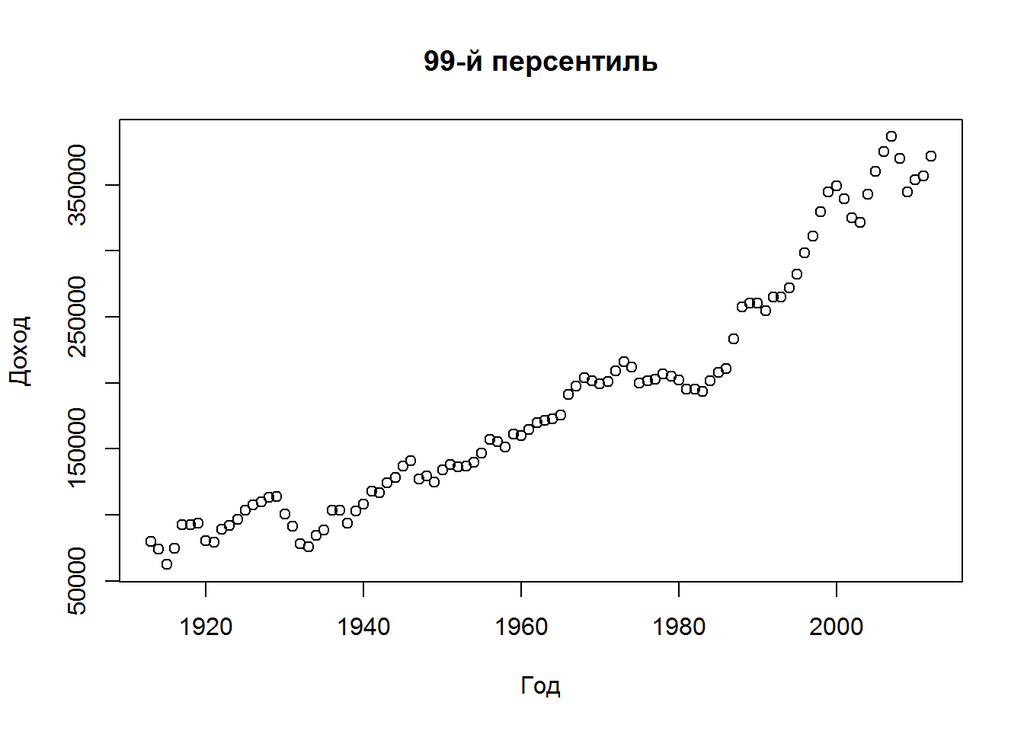

```r
plot(data$Year, data$P99, xlab = "Год", ylab = "Доход", main = "99-й персентиль")
```

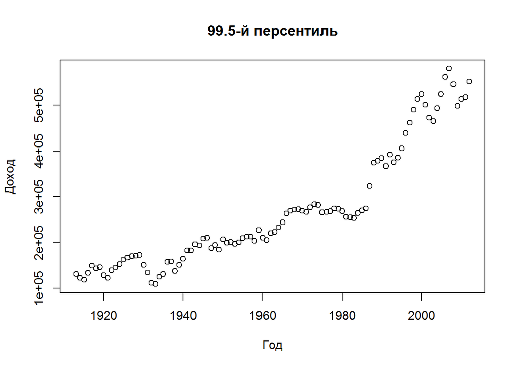

```r
plot(data$Year, data$P99.5, xlab = "Год", ylab = "Доход", main = "99.5-й персентиль")
```

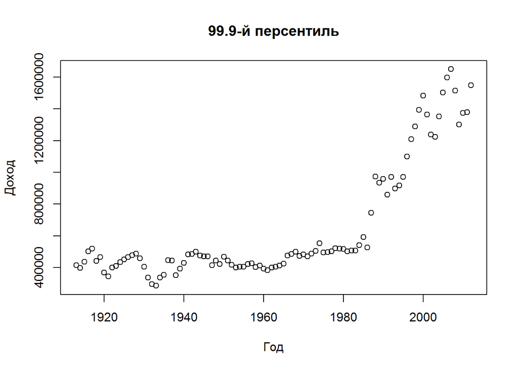

```r
plot(data$Year, data$P99.9, xlab = "Год", ylab = "Доход", main = "99.9-й персентиль")
```

3. Из предыдущих вычислений можно получить, что оценить параметр a можно по следующей формуле: a = 1 - log(10)/log(P99/P99.9) (3). Напишите функцию my.exp.estimate_ratio, которая принимает аргументы P99 и P99.9 и возвращает a, рассчитанное по формуле (3). Проверьте, что при P99 = 1e6 и P99.9 = 1e7 функция вернёт a = 2.

```r
my.exp.estimate_ratio <- function(P99, P99.9)
{
  a = 1-log(10)/log(P99/P99.9)
  return(a)
}
my.exp.estimate_ratio(10**6,10**7)
```

```
## [1] 2
```